# Experimentos com o watershed

## Segmentação: Watershed

Para isso, usarei bibliotecas como NumPy, Matplotlib, Scikit-learn e Scikit-image...

```python
import numpy as np
import matplotlib.pyplot as plt


# Configurações de exibição do matplotlib
%matplotlib inline
plt.rcParams['image.interpolation'] = 'nearest'
plt.rcParams['image.cmap'] = 'gray'
plt.rcParams['figure.dpi'] = 100
```

Todas as imagens de `./dataset/*.jpg` são carregadas, mas por estarem em alta resolução, eu irei rudizir suas dimensões proporcionalmente de modo que as larguras e/ou alturas sejam, no máximo, menor ou igual à `msize`.

É importe ressaltar que, como as imagens estão sendo carregadas ordenadas pelo nome do arquivo (através da função `sorted`), **as primeiras 5 imagens da lista são as fotografadas e o restante, as escaneadas**.

```python
from skimage import transform, io
from glob import glob


def img_resize(image, msize=500):
    t = msize / max(image.shape)
    n = tuple([int(s * t) for s in image.shape[:2]])
    return transform.resize(image, n, mode='reflect')


imgs = []
for file in sorted(glob("./dataset/*.jpg")):
    imgs.append([file.split('/')[-1], img_resize(io.imread(file))])
```

Acima, as imagens (fotogradas e escaneadas) são carregas em uma lista, sendo que cada item dessa lista encontra-se no seguinte formato: `[str("..."), np.array()]`, onde a primeira posição armazena o nome do arquivo enquanto que a segunda, a imagem em um numpy array.

Agora as imagens passarão por um Processamento Digital de Imagens (PDI) básico, onde será utilizado apenas o algoritmo [*Total Variation Denoising*](https://en.wikipedia.org/wiki/Total_variation_denoising). A implementação utilizada neste experimento é a de *Chambolle, A. (2004)*, disponibilizada no Scikit-image. A documentação pode ser encontrada [aqui](http://scikit-image.org/docs/dev/api/skimage.restoration.html#skimage.restoration.denoise_tv_chambolle) e é importante ressaltar que **a imagem enviada ao algoritmo será convertida para tons de cinza** para otimizar o processo. Por fim, após a aplicação do algoritmo em cada imagem, o resultado é anexado à lista `imgs`.

```python
from skimage.restoration import denoise_tv_chambolle
from skimage.color import rgb2gray


def pdi(image):
    gray = rgb2gray(image)
    return denoise_tv_chambolle(gray, weight=0.25, multichannel=False)


for img in imgs:
    img.append(pdi(img[1]))
```

Abaixo, vamos plotar um "antes e depois" das imagens. Na primeira linha encontram-se as imagens carregadas do diretório indicado, sem nenhuma alteração além do redimensionamento, enquanto que a segunda linha expõe as mesmas imagens após o PDI (processo realizado no bloco anterior)

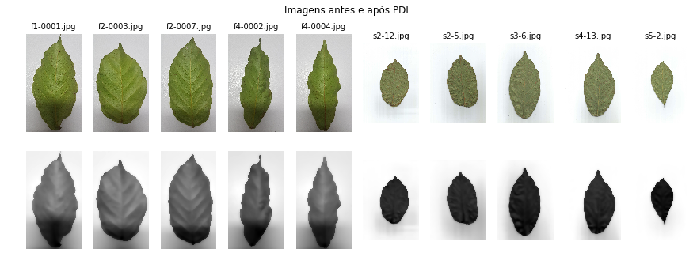

```python
f, ax = plt.subplots(2, 10, figsize=(15, 5))
f.suptitle("Imagens antes e após PDI")

for i in range(2):
    x = 0
    for j in range(10):
        ax[i, j].set_title(imgs[x][0], size=10) if i == 0 else None
        ax[i, j].imshow(imgs[x][1 if i == 0 else 2])
        ax[i, j].axis('off')
        x += 1
```

Diferentemente dos experimentos realizados com o algoritmo K-Means, que baseia-se necessariamente nas cores da imagem para realizar o processo de segmentação, com o algoritmo *watershed* as cores não possuem elevada significância. Isso ocorre devido à arquitetura do algoritmo que necessita, ao invés de canais de cor, de *seeds* (sementes; *i.e.*, pontos específicos na imagem destacados "manualmente") para orientar seu processo de segmentação. Dessa forma, é possível definir as *seeds* até mesmo em imagens com um único canal (escala cinza). Tal abordagem com imagens em tons de cinza possui vantagens, visto que os cálculos são realizados em apenas um canal.

Em relação às *seeds* (também chamadas de marcadores), poderíamos defini-las manualmente. Entretanto, para deixar o proceso mais automatizado, iremos alocar os marcadores nas regiões de baixo gradiente dentro da imagem, conforme [este link](http://scikit-image.org/docs/dev/auto_examples/segmentation/plot_marked_watershed.html) apresenta.

Para esse processo, temos que calcular o gradiente da imagem que, por sua vez, é encontrado através do módulo das derivadas em $x$ e $y$ da imagem. Essas derivadas podem ser estimadas a partir da convolução destas com um *kernel* (também chamado de filtro e mascára) pequeno (geralmente $2\times2$ ou $3\times3$), assim como os operadores de [Sobel-Feldman](https://en.wikipedia.org/wiki/Sobel_operator) *(usarei este)* e [Prewitt](https://en.wikipedia.org/wiki/Prewitt_operator). Desta forma, considerando que o **k**ernel de Sobel-Feldman para as componentes $x$ e $y$ é:

\begin{equation*} Kx = \begin{vmatrix} 1 & 0 & -1\\ 2 & 0 & -2\\ 1 & 0 & -1 \end{vmatrix}, Ky = Kx^T\ \end{equation*}

A derivada de uma imagem $f(x, y)$ em $x$ é:

\begin{equation*} \frac{\partial f}{\partial x} = f \circledast Kx \end{equation*}

enquanto que em $y$:

\begin{equation*} \frac{\partial f}{\partial y} = f \circledast Ky \end{equation*}

Por fim, já com as duas derivadas formuladas, podemos encontrar o gradiente ($G$) da imagem:

\begin{equation*} G = \sqrt{{\frac{\partial f}{\partial y}}^2 + {\frac{\partial f}{\partial x}}^2} \end{equation*}

Como resultado, $G$ é uma matriz com as bordas de $f(x, y)$ destacadas. Iremos codificar esses procedimentos na função `g_sobel`:

```python
from scipy import ndimage as ndi


# Essa é a implementação de 'G', esse processo é também conhecido como Filtro de Sobel-Feldman.
# 'f' é a imagem de entrada. Ela deve conter apenas um canal de cor.
def g_sobel(f):
    kx = np.array([
        [1, 0, -1],
        [2, 0, -2],
        [1, 0, -1]
    ])
    ky = kx.T
    dx = ndi.convolve(f, kx)
    dy = ndi.convolve(f, ky)
    return np.sqrt(np.power(dx, 2) + np.power(dy, 2))
```

Para, mais tarde, alocarmos os marcadores nas regiões de baixo gradiente, precisaremos de um *threshold* para identificar tal região. Atualmente, o gradiente ($G$) que é calculado pela função acima `g_sobel` retorna uma imagem com um *range* de intensidade dos pixels bastante grande (como, por exemplo, de ${2.1}e^{-5}$ até $1.6$). Vamos normalizar isso, de modo que a intensidade de cada pixel fique entre $0$ e $255$, ocupando apenas 1 Byte em memória. Para isso, eu criei a função `norm_colorspace` que implementa

\begin{equation*} \sum_{i=0}^{w} \sum_{j=0}^{h} \bigg(\frac{f(i,j)-pixelMin}{pixelMax-pixelMin}\bigg)\times 255 \end{equation*}

para a imagem/parâmetro `f`; onde $f(i,j)$ é o valor do pixel a ser convertido, $pixelMin$ e $pixelMax$ são, respectivamente, o menor e o maior valor de intensidade/pixel da imagem.

```python
def norm_colorspace(f):
    pixelMin, pixelMax = np.min(f), np.max(f)
    return np.uint8(((f[:, :] - pixelMin)/(pixelMax - pixelMin))*255)
```

Abaixo, a função `g_sobel` calcula o gradiente de cada imagem (que já passaram pelo PDI) da lista `imgs`, logo em seguida os valores dos pixels são normalizados pela função `norm_colorspace` e, finalmente, o resultado é adicionado na últmia posição de `imgs`.

```python
for img in imgs:
    g = g_sobel(img[2])
    img.append(norm_colorspace(g))
```

Podemos, agora, observar o gradiente de cada imagem da lista:

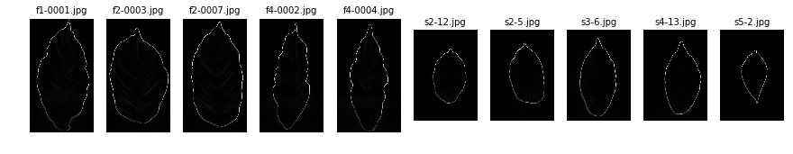

```python
f, ax = plt.subplots(1, 10, figsize=(15, 5))

for i in range(10):
    ax[i].set_title(imgs[i][0], size=10)
    ax[i].imshow(imgs[i][3])
    ax[i].axis('off')
```

As bordas visíveis são, basicamente, regiões que possuem altos valores de gradiente. Nesse tipo de dado (imagens acima), as áreas de valores altos fornecem barreiras que ajudam a segmentar a imagem, e o uso de marcadores nos valores mais baixos assegurará que os objetos segmentados sejam encontrados.

A função `set_markers` nos ajudará no processo de isolamento das regiões de baixo gradiente, utilizando um limiar `thr_low` que pode ser definido entre 0 e 255 (para esse contexto, a melhor configuração é $5 <$ `thr_low` $< 30$).

```python
from scipy import ndimage as ndi


def set_markers(image, thr_low=15):
    low_g_region = image < thr_low
    return ndi.label(low_g_region)[0]
```

Agora que já temos "barreiras" (bordas) definidas na imagem (calculadas através do gradiente) e os marcadores, podemos iniciar o segmentador *Watershed* passando esses nossos dados como parâmetros:

```python
from skimage.morphology import watershed
from skimage.filters import threshold_otsu


def mask(image, segmentation):
    out = image.copy()
    binary = segmentation > threshold_otsu(segmentation)
    for i in range(3):
        out[:,:,i] *= binary
    return out


for img in imgs:
    im_g = img[3]
    labels = watershed(im_g, set_markers(im_g))
    img.append(labels)
    img.append(mask(img[1], labels))
```

A função `mask`, basicamente, binariza o resultado da segmentação realizada pelo *watershed* e, em seguida, aplica a mascára à imagem original, através de uma multiplicação. Com isso, áreas de baixas frequências na máscara são removidas na mesma posição da imagem original. As máscaras encontradas com o *watershed* podem ser vistas abaixo:

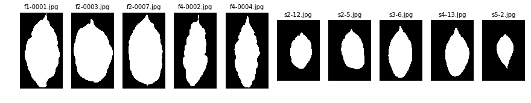

```python
f, ax = plt.subplots(1, 10, figsize=(15, 5))

for i in range(10):
    ax[i].set_title(imgs[i][0], size=10)
    ax[i].imshow(imgs[i][4] > threshold_otsu(imgs[i][4]))
    ax[i].axis('off')
```

Como resultado da multiplicação entre as máscaras e imagens originais, temos:

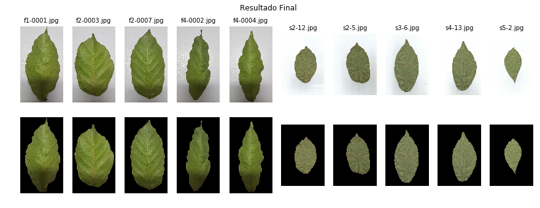

```python
f, ax = plt.subplots(2, 10, figsize=(15, 5))
f.suptitle("Resultado Final")

for i in range(2):
    x = 0
    for j in range(10):
        ax[i, j].set_title(imgs[x][0], size=10) if i == 0 else None
        ax[i, j].imshow(imgs[x][1 if i == 0 else 5])
        ax[i, j].axis('off')
        x += 1
```

### Conclusões

Este experimento utilizou 10 amostras de folíolos dos cultivares de guranazeiros, sendo uma metáde composta de imagens fotografadas e outra de escaneadas, para testar a eficácia de segmentação do algoritmo de segmentação *watershed*.

Ao longo dos testes, observou-se que a qualidade da segmentação dos folíolos não ficou completamente associada às técnicas de PDI utilizadas. Isso é bastante interessante pois permitiu certa economia de tempo, em relação ao K-Means, testado anteriormente.

Acredita-se que essa não alta dependência de PDI deve-se aos mecanismos de funcionamento interno do *watershed* que, ao invés de utilizar apenas as cores como parâmetro de segmentação, utiliza *seeds*/marcadores, o que lhe proporciona resultados satisfatórios, principalmente neste contexto (segmentação de folíolos). Entretanto, esse algoritmo possui uma carga teórica de entendimento bem mais densa que o K-Means, principalmente quando objetiva-se definir os marcadores sem tanta interferência humana. Neste caso, para essa tarefa, os marcadores foram alocados nas regiões de baixo gradiente na imagem.

Outros algoritmos similares ao *watershed*, como o [*Randon Walker*](https://en.wikipedia.org/wiki/Random_walker_algorithm), ainda podem ser testados e comparados.